# Airbnb Exploratory Analysis

Eddie Liu, Gabriel Roth, Edward Lara, Shuangning Yang

December 1, 2019

# Introduction and Research Objective

AirBNB’s website contains a collection of datasets that summarize its users’ listings internationally. Our group decided to narrow our focus on the listings dataset of the greater Los Angeles area because we are interested in analyzing possible factors that affect the rental prices. Because there is information for over 200 neighorhoods, we looked at the rentals of the major cities in western Los Angeles as this area encompasses UCLA. We decided to examine if the room type and location, described as neighborhood in the dataset, affect the price of a listing, and if so how they affect the price of a listing. We start off by visualizing the relationships between these variables in order to identify any patterns. Using a multiple linear regression model, we attempt to quantify the significance of the variables of interest in terms of a prediction standpoint.

# Visualizations

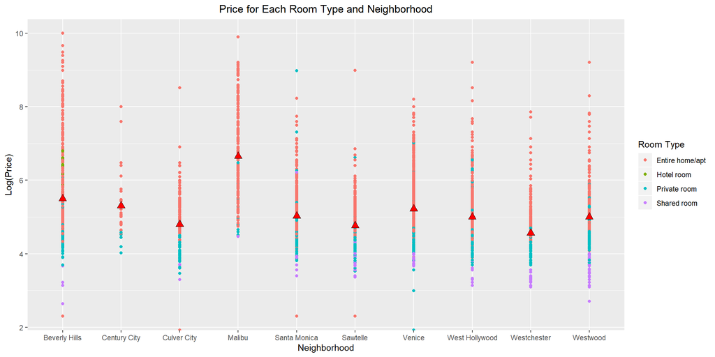

Here we measure the Log of the Price variable in order to better visualize the scale of the prices. From the start, we see that in the West Los Angeles area, Malibu has the highest average listing price regardless of room type. Westchester on the other has the lowest average listing price. Examining room type, we see that entire homes/ apts dominate the higher price ranges while shared rooms mainly occupy the lower price ranges. Hotel rooms seem to rank right after entire homes/ apts followed by private rooms.

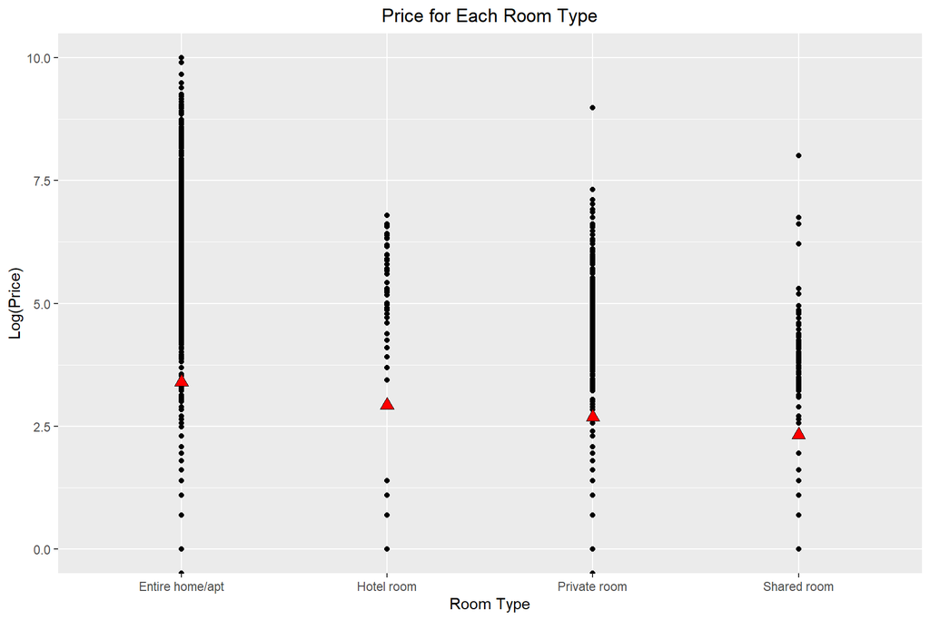

In this plot, we reaffirm our observations earlier about pricing by room type. It is important to note that there is a bit of variation with each room type, most notably with Hotel rooms and Shared rooms.

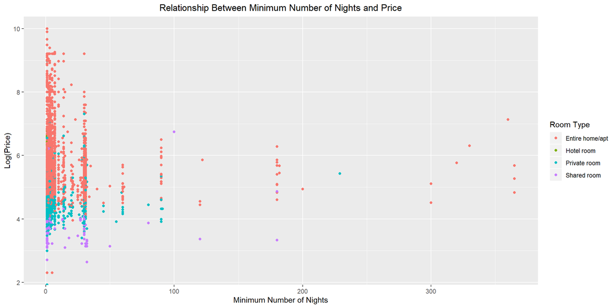

Here we examine the Minimum Number of Nights against the price. Most listings have a minimum number of nights below 50. We hypothesize that the values above 50 are outliers and may be due to user inputted errors. The graph here does not seem to indicate a clear trend between these two variables.

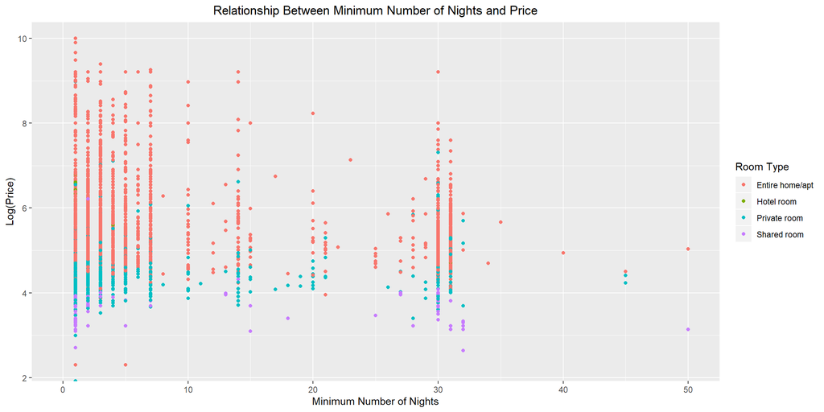

Here we take a look at all entires that have a Minimum Number of Nights under 50. There again does not seem to be a clear trend.

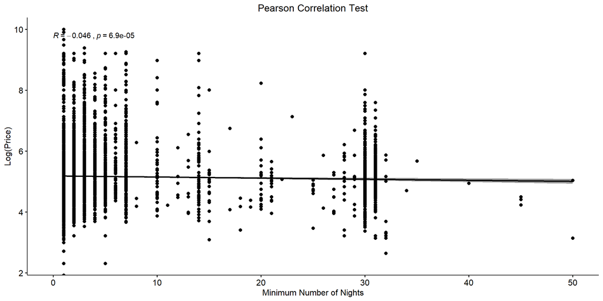

The Pearson Correlation Test results indicate that there is a very slight (almost negligible) negative correlation between Log(Price) and Minimum Number of Nights. Although this is very slight, a possible reason for this may due to the risk associated with a higher minimum number of nights. These listings have less flexibility and thus may require less of a price as compensation for the lowered flexibility.